# Solution to Bayesian Inference problems

David Klinke

2022-10-18

1. In a research program on human health risk from recreational contact with water contaminated with pathogenic microbiological material, the National Institute of Water and Atmosphere (NIWA) in New Zealand instituted a study to determine the quality of water at a variety of catchment types. In a site identified as having a heavy environmental impact from seagulls and waterfowl, 116 one-liter water samples were acquired an analyzed. Out of those samples, 17 samples contained pathogenic *Giardia* cysts.
- What distribution can be used to describe the number of samples containing *Giardia* cysts?

Since the outcome seems to be whether or not the samples contain pathogenic *Giardia* cysts, the observations are likely to be described by a binomial distribution with n = 116 and the probability of obtaining a contaminated sample equal to $\theta$.

- Let $\theta$ be the probability that a one-liter water sample from this type of site contains *Giardia* cysts. Use a uniform prior for $\theta$. Find the posterior distribution of $\theta$, given the data.

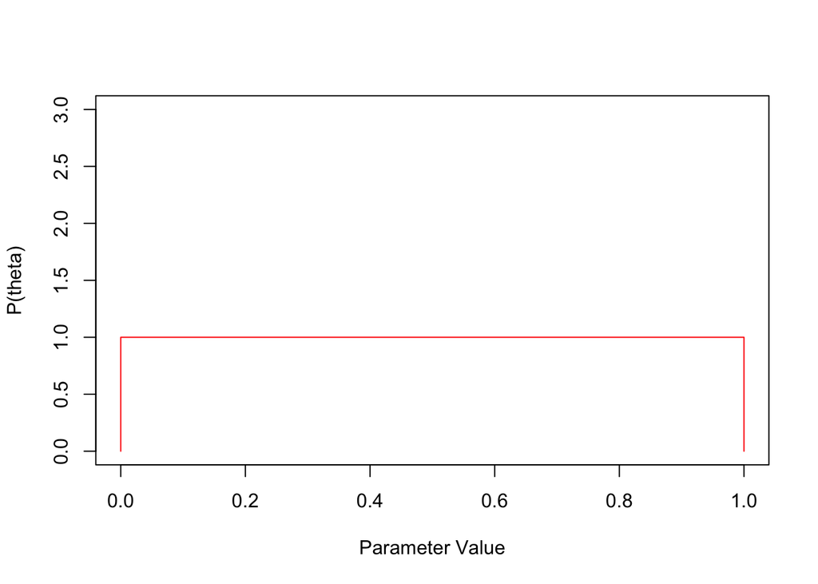

```r
Param <- seq(0, 1, by = 0.01)
Prior <- rep(1, length(Param))
Init <- data.frame(Parameter = Param, Prior = Prior)
# add some zeros to the front and end to make the plot prettier
plot(c(0, Init$Parameter, 1), c(0, Init$Prior, 0), type = "l", col = "red", xlab = "Parameter Value", ylab = "P(theta)", ylim = c(0, 3))
```

The **likelihood** corresponds to the likelihood for observing data similar to that actually observed (17 “successes” in 116 trials), given a particular value of the model parameter.

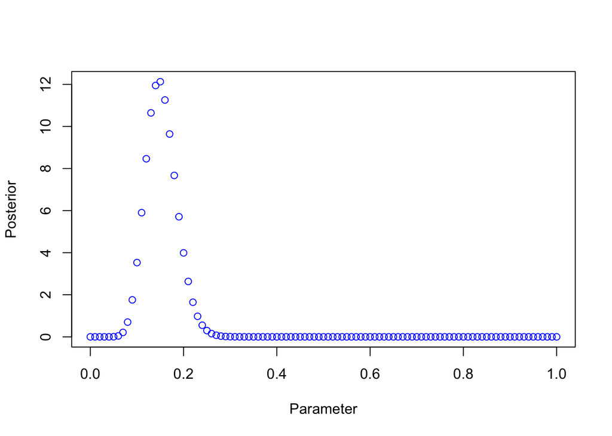

```r
likelihood.prior <- apply(Init, 1, function(x) dbinom(17, 116, x['Parameter']) * x['Prior'])

ntrap <- length(likelihood.prior) - 1
h <- (1 - 0)/ntrap
Evidence <- h*(likelihood.prior[1]/2 + sum(likelihood.prior[2:ntrap]) + likelihood.prior[ntrap+1]/2)

Posterior <- likelihood.prior/Evidence
plot(Init$Parameter, Posterior, type = "p", col = "blue", xlab = "Parameter", ylab = "Posterior")
```

- Summarize the posterior distribution by its first two moments.

```r
# where is maximum
Mean <- sum(Init$Parameter * Posterior)*h
Sigma <- sqrt(sum((Init$Parameter - Mean)^2 * Posterior)*h)
```

- Compare the posterior distribution in $\theta$ against a normal distribution parameterized by the first two moments. Quantitatively compare the distributions.

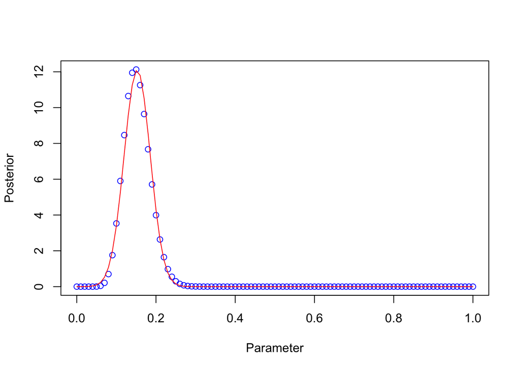

```r
plot(Init$Parameter, Posterior, type = "p", col = "blue", xlab = "Parameter", ylab = "Posterior")
lines(Init$Parameter, dnorm(Init$Parameter, mean = Mean, sd = Sigma), col = "red")
```

- Compute a 95% high density interval for $\theta$

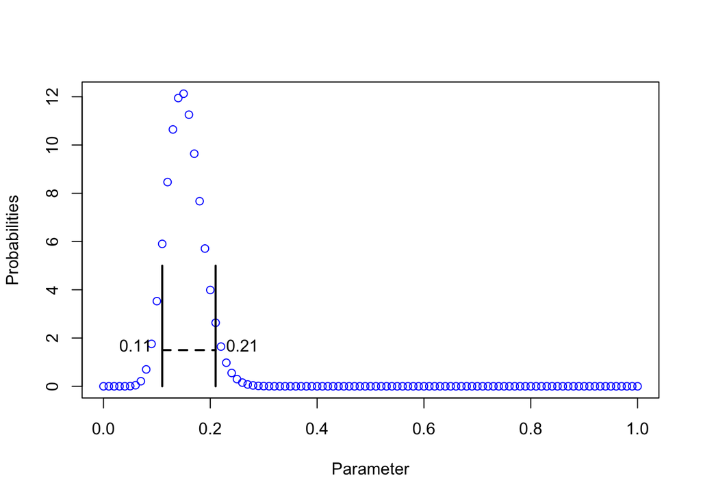

```r
# let's determine 95% High Density Interval
lx <- 2
lefttail = 0
while (lefttail < 0.025){
  if(lx == 2){
    lefttail = h/2*sum(likelihood.prior[1:lx])/Evidence
  } else {
    lefttail = h/2*(likelihood.prior[1] + 2*sum(likelihood.prior[2:lx-1]) + likelihood.prior[lx])/Evidence
  }
  lx <- lx + 1
}

rx <- length(likelihood.prior)
righttail = 1
while (righttail > 0.975){
  righttail = h/2*(likelihood.prior[1] + 2*sum(likelihood.prior[2:rx-1]) + likelihood.prior[rx])/Evidence
  rx <- rx - 1
}

plot(Init$Parameter, Posterior, type = "p", col = "blue", xlab = "Parameter", ylab = "Probabilities")
lines(c(Init$Parameter[lx], Init$Parameter[rx]), c(1.5, 1.5), lwd = 2, lty = 2, col = "black")
lines(c(Init$Parameter[lx], Init$Parameter[lx]), c(0, 5), lwd = 2, lty = 1, col = "black")
lines(c(Init$Parameter[rx], Init$Parameter[rx]), c(0, 5), lwd = 2, lty = 1, col = "black")
text(Init$Parameter[lx]-0.05, 1.7, label = as.character(Init$Parameter[lx]))
text(Init$Parameter[rx]+0.05, 1.7, label = as.character(Init$Parameter[rx]))
```

2. An engineer takes a sample of 5 steel I beams from a batch, and measured the amount they sag under a standard load. The amounts in mm are: 5.19, 4.72, 4.81, 4.87, 4.88. It is known that the sag follows a normal distribution.
- Use a normal prior for $\mu$ and a flat prior for $\sigma$ informed by the sample mean and standard deviation. Find the posterior distribution of the parameters.

```r
sample1 <- c(5.19, 4.72, 4.81, 4.87, 4.88)

yb <- mean(sample1)
n2 <- length(sample1)
s2 <- sum((sample1 - yb)^2) / (n2 - 1)

n <- 100 # grid points
# mu is parameter 1 and sigma is parameter 2
h1 <- (80*s2)/n
h2 <- (4*s2 - 0.001)/n
mui <- seq(yb - 40*s2, yb + 40*s2, by = h1)
sgi <- seq(0.001, 4*s2, by = h2)
wij <- matrix(c(0.25, rep(0.5, n-1), 0.25, rep(c(0.5, rep(1, n-1), 0.5), n-1),
              0.25, rep(0.5, n-1), 0.25), nrow = n+1, ncol = n+1, byrow = TRUE)
mu.vec <- matrix(data = mui, nrow = n+1, ncol = n+1, byrow = FALSE)
mu.prior <- matrix(data = dnorm(mui, mean = yb, sd = sqrt(s2)), nrow = n+1, ncol = n+1, byrow = FALSE)

sg.vec <- matrix(data = sgi, nrow = n+1, ncol = n+1, byrow = TRUE)
# assuming prior values are equal to 1 - the particular value will cancel out
sg.prior <- matrix(data = 1, nrow = n+1, ncol = n+1, byrow = TRUE)

theta.vec <- data.frame(mu = as.vector(mu.vec), sigma = as.vector(sg.vec), prior = as.vector(mu.prior)*as.vector(sg.prior))
```

We will calculate the likelihood for every combination of parameter values and do the integration to estimate the *Evidence*.

```r
likelihood <- function(mu, sigma, ybar, s, n){
  res <- (1/(2 * pi * sigma^2)^n) * exp(- ((n - 1)*s^2 + n*(ybar - mu)^2)/(2*sigma^2))
  return(res)
}

likelihood.prior.vec <- apply(theta.vec, 1, function(x) likelihood(x['mu'], x['sigma'], yb, s2, n2) * x['prior'])

Evidence <- h1*h2*sum(as.vector(wij)*likelihood.prior.vec)
```

Using the *Evidence* we can then plot the posterior distribution over the range of parameter values.

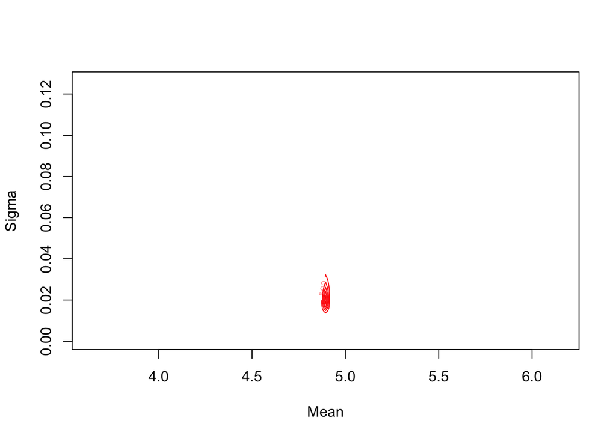

```r
Posterior <- likelihood.prior.vec/Evidence

contour(mui, sgi, matrix(Posterior, nrow = n+1, ncol = n+1, byrow = FALSE), col = "red", xlab = "Mean", ylab = "Sigma")
```

- For a batch of I beams to be acceptable, the mean sag under the standard load must be less than 5.20. Explicitly state your decision making criteria.

The two alternative hypotheses are:
$$\begin{eqnarray}
H_0: \textrm{mean sag} < 5.20\\
H_1: \textrm{mean sag} \ge 5.20
\end{eqnarray}$$

- Make a decision, assuming that you have a 5% chance of being wrong.

```r
# Making sure that the posterior sums to 1
h1*h2*sum(Posterior)
```

```
## [1] 1
```

```r
# Summing up the posterior with values of mu greater than or equal to 5.20
result <- h1*h2*sum(Posterior[theta.vec$mu >= 5.20])
```